# Ejercicios de repaso Variables Aleatorias

Jesús Joana (jesusjoanaazuara@gmail.com)

# EJERCICIO 1

1. Encuentra la funci´on de probabilidad de ni˜nos y ni˜nas en familas con 3 hijos, suponiendo igual probabilidad para ni˜nos y ni˜nas.

```r
i <- 0:3
resultado <- dbinom(i, 3, prob = 0.5)
print(resultado)
```

```
## [1] 0.125 0.375 0.375 0.125
```

2. Encuentra la funci´on de distribuci´on para la variable aleatoria del apartado a).

```r
i <- 0:3
resultado2 <- pbinom(i, 3, prob = 0.5)
print(resultado2)
```

```
## [1] 0.125 0.500 0.875 1.000
```

3. Dibuja la funci´on de distribuci´on.

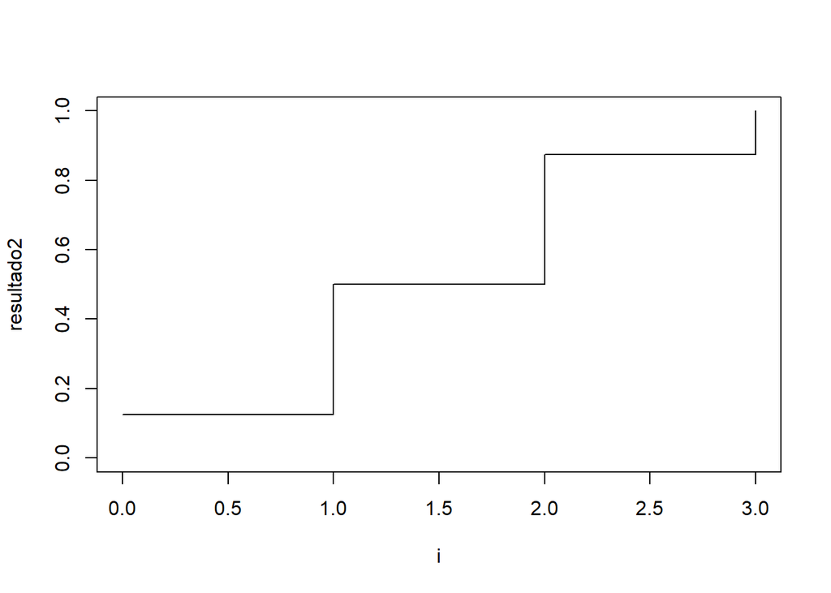

```r
plot(i, resultado2, type = "s", xlim = c(0, 3), ylim = c(0, 1))
```

4. Imag´ınate que el ´unico dato del que partes es la funci´on de distribuci´on. ¿C´omo podr´ıas hallar la funci´on de probabilidad?

```r
f_0 <- pbinom(0,3, prob = 0.5)
f_1 <- pbinom(1, 3, prob=0.5) - pbinom(0, 3, prob=0.5)
f_2 <- pbinom(2, 3, prob=0.5) - pbinom(1, 3, prob=0.5)
f_3 <- pbinom(3, 3, prob = 0.5) - pbinom(2, 3, prob = 0.5)
print(c(f_0, f_1, f_2, f_3))
```

```
## [1] 0.125 0.375 0.375 0.125
```

# EJERCICIO 2

Se realizan 12 lanzamientos de una moneda equilibrada. Determinar la distribuci´on del n´umero de caras obtenidas.

```r
i <- 0:12
r2 <- dbinom(i, 12, prob = 0.5)
print(r2)
```

```
##  [1] 0.0002441406 0.0029296875 0.0161132813 0.0537109375 0.1208496094
##  [6] 0.1933593750 0.2255859375 0.1933593750 0.1208496094 0.0537109375
## [11] 0.0161132813 0.0029296875 0.0002441406
```

```r
simulacion <- rbinom(10000000, 12, prob = 0.5)
num_6 <- sum(simulacion == 6)
prob_6 <- num_6/10000000
prob_6
```

```
## [1] 0.2255671
```

Se realizan 12 lanzamientos de una moneda equilibrada. Determinar la distribución de la diferencia entre caras y cruces (pista: nº de cruces = 12 - nº de caras). En cada caso, representar la función de probabilidad para caracterizar la distribución.

```r
i <- 0:12

r3 <- dbinom(i, 12, prob = 0.5)
solucion <- 2*i - 12

print(c(r3, solucion))
```

```
##  [1]  2.441406e-04  2.929688e-03  1.611328e-02  5.371094e-02  1.208496e-01
##  [6]  1.933594e-01  2.255859e-01  1.933594e-01  1.208496e-01  5.371094e-02
## [11]  1.611328e-02  2.929688e-03  2.441406e-04 -1.200000e+01 -1.000000e+01
## [16] -8.000000e+00 -6.000000e+00 -4.000000e+00 -2.000000e+00  0.000000e+00
## [21]  2.000000e+00  4.000000e+00  6.000000e+00  8.000000e+00  1.000000e+01
## [26]  1.200000e+01
```

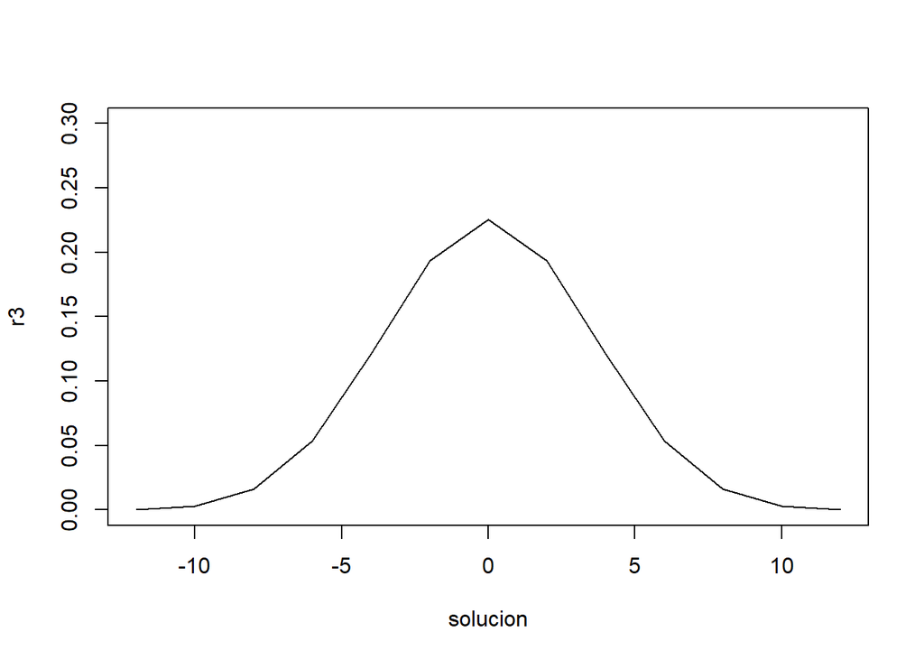

```r
# Representación de la distribución

plot(solucion, r3, type = "l", xlim = c(-12,12), ylim = c(0,0.3))
```

# EJERCICIO 8

Una máquina fabrica tornillos de los cuales el 10% son defectuosos. Encuentra la probabilidad de que en una muestra tomada al azar de 400 tornillos

1. Como máximo 30 de los tornillos sean defectuosos.

```r
tornillos <- pbinom(30, 400, 0.10)
# tornillos2 <- pbinom(369, 400, 0.90, lower.tail = FALSE) sirve para lo mismo
print(tornillos)
```

```
## [1] 0.05239125
```

2. Entre 30 y 50 de los tornillos sean defectuosos.

```r
resultado <- pbinom(50, 400, 0.10) - pbinom(29, 400, 0.10)
resultado
```

```
## [1] 0.920695
```

3. 65 o más, de los tornillos sean defectuosos.

```r
resultado <- pbinom(64, 400, 0.10, lower.tail = FALSE)
resultado
```

```
## [1] 7.036756e-05
```

# EJERCICIO 11

Calcular:

```r
# a) la constante c

# Ajustar (calcular) el valor de la constante c para que f(x) represente correctamente una función de densidad. Es decir, la integral de la función de densidad en el rango de valores de X, valga 1

densidad <- function(x){
  probabilidad <- exp(-3*x)
}

resultado <- integrate(densidad, lower=0, upper=Inf)$value
resultado
```

```
## [1] 0.3333333
```

```r
c <- 1/resultado
c
```

```
## [1] 3
```

```r
densidad_normalizada <- function(x){
  probabilidad <- c*exp(-3*x)
}

area <- integrate(densidad_normalizada, lower=0, upper=Inf)$value
area
```

```
## [1] 1
```

```r
# b) P(1 < X < 2)

probabilidad <- integrate(densidad_normalizada, lower = 1, upper = 2)$value
probabilidad
```

```
## [1] 0.04730832
```

```r
# c) P(X ≥ 3)

p2 <- integrate(densidad_normalizada, lower = 3, upper = Inf)$value
p2
```

```
## [1] 0.0001234098
```

```r
# d) P(X < 1)
p3 <- integrate(densidad_normalizada, lower = 0, upper = 1)$value
p3
```

```
## [1] 0.9502129
```